# Proyecto de análisis de datos de Bellabeat

Fabián Barragán Barriga

# 1. Resumen de tarea empresarial

## Introducción y Contexto empresarial

Bellabeat es una empresa fabricante de productos de alta tecnología orientados a la salud de la mujer. Bellabeat es una empresa pequeña exitosa, pero tiene el potencial para convertirse en un actor más grande en el mercado global de dispositivos inteligentes.

### 1.1 Hipótesis inicial

Una de las principales cofundadoras de la empresa (Urška Sršen) tiene la hipótesis inicial que si se analizaran datos de la actividad física de los dispositivos inteligentes de podría desplegar nuevas oportunidades de negocio para la empresa.

### 1.2 Actores

1. **Urška Sršen**: confundadora y directora creativa de Bellabeat
2. **Sando Mur**: matemático, confundador y ejecutivo de la empresa
3. **Equipo de análisis computacional de datos de marketing de Bellabeat**

### 1.3 Recursos tecnológicos disponibles

1. **App Bellabeat**: aplicación que ayuda a los usuarios a comprender sus hábitos actuales para tomar decisiones salusables, esto se logra con la recopilación de datos sobre *Actividad física*, *sueño*,*estrés*,*ciclo menstrual*, *hábitos de conciencia*.Esta app está conectada a los gadgets.
2. **Leaf**: gadget (pulsera,collar,clip) conectada a la app de bellabeat para recopilar datos sobre *Actividad física*, *sueño*, *estrés*.
3. **Time**: smartwatch con el mismo propósito.
4. **Spring**: botella de agua que recopila datos de que tanta agua se toma en el día para *recopilar datos sobre tu hidratación*.
5. **Membresía bellabeat**: Acceso 24/7 sobre orientación personalizada sobre temas de nutrición, actividad física, sueño, salud, bellaza y **mindfullnes**.

### 1.4 Tarea Empresarial

CONSIGNA:

Analizar el uso de gadgets de usuarios que **NO** son de bellabeats para aplicar este conocimiento en la empresa y finalmente presentarlo.

```
Puntos clave:

    1. Encontrar la tendencias de uso de los gadgets de los usuarios de otras aplicaciones.

    2. Buscar la manera de usar estas tendencias para los usuarios de Bellabeat.

    3. Lograr que estas tendencias ayuden a influir en la estrategia de marketing de bellabeat
```

# 2. Preparación de datos

### Justificación de uso del dataset

Primeramente se usarán datos públicos que exploren los **hábitos cotidianos de los usuarios de dispositivos inteligentes**, estos datos serán sacados de **Kaggle**, más específicamente del dataset [FitBit Fitness Tracker Data](https://www.kaggle.com/datasets/arashnic/fitbit).

Este conjunto de datos de Kaggle contiene el seguimiento de la actividad física personal en treinta usuarios de Fitbit. Treinta usuarios elegibles de Fitbit prestaron su consentimiento para el envío de datos personales de seguimiento que incluyen rendimiento de la actividad física en minutos, ritmo cardíaco y monitoreo del sueño. Incluye información sobre la actividad diaria, pasos y ritmo cardíaco que se puede usar para explorar los hábitos de los usuarios.

Del Dataset original, usaremos solamente las Base de datos que a primera vista parezcan que puedan ayudarnos a resolver nuestra tarea empresarial, los cuales son:

1. **dailyActivity_merged.csv** para analizar el registro de actividad diaria
2. **hourlyCalories_merged.csv** para observar cuál es momento del día donde se queman más calorias y podría estar relacionado con la actividad diaria.
3. **hourlyIntensities_merged.csv** para observar cuál es momento del día donde el cuerpo tiene la mayor intensidad en sus movimientos, lo que podría estar relacionado con los puntos anteriores.
4. **sleepDay_merged.csv** para analizar hábitos de sueño.
5. **weightLogInfo_merged.csv** para analizar el seguimiento de peso de los usuarios.

### Cargando las paqueterías para análisis de datos

```r
library(ggplot2)
library(tidyr)
library(readr)
library(dplyr)
library(skimr)
library(here)
library(janitor)
library(lubridate)
```

### Cargando las bases de datos correspondiantes

```r
setwd("/home/fabian/R/proyectos/analisis-bellabeat/datasets")
act_diaria <- read.csv("dailyActivity_merged.csv")
calorias <- read.csv("hourlyCalories_merged.csv")
intensidad <- read.csv("hourlyIntensities_merged.csv")
tiempo_sueno <- read.csv ("sleepDay_merged.csv")
track_peso <- read.csv("weightLogInfo_merged.csv")
```

### 2.1 Pre-exploración de datos

Lo primero que haremos es visualizar el panorama general de los marcos de datos con los que estamos trabajando, los ordenaremos y filtraremos con el propósito de obtener un subconjunto de datos más manejable para nuestro análisis. Más adelante transforaremos datos para garantizar la integridad de los datos y proceder con el análisis.

```r
glimpse(act_diaria)
```

```
## Rows: 940
## Columns: 15
## $ Id                       <dbl> 1503960366, 1503960366, 1503960366, 150396036…
## $ ActivityDate             <chr> "4/12/2016", "4/13/2016", "4/14/2016", "4/15/…
## $ TotalSteps               <int> 13162, 10735, 10460, 9762, 12669, 9705, 13019…
## $ TotalDistance            <dbl> 8.50, 6.97, 6.74, 6.28, 8.16, 6.48, 8.59, 9.8…
## $ TrackerDistance          <dbl> 8.50, 6.97, 6.74, 6.28, 8.16, 6.48, 8.59, 9.8…
## $ LoggedActivitiesDistance <dbl> 0, 0, 0, 0, 0, 0, 0, 0, 0, 0, 0, 0, 0, 0, 0, …
## $ VeryActiveDistance       <dbl> 1.88, 1.57, 2.44, 2.14, 2.71, 3.19, 3.25, 3.5…
## $ ModeratelyActiveDistance <dbl> 0.55, 0.69, 0.40, 1.26, 0.41, 0.78, 0.64, 1.3…
## $ LightActiveDistance      <dbl> 6.06, 4.71, 3.91, 2.83, 5.04, 2.51, 4.71, 5.0…
## $ SedentaryActiveDistance  <dbl> 0, 0, 0, 0, 0, 0, 0, 0, 0, 0, 0, 0, 0, 0, 0, …
## $ VeryActiveMinutes        <int> 25, 21, 30, 29, 36, 38, 42, 50, 28, 19, 66, 4…
## $ FairlyActiveMinutes      <int> 13, 19, 11, 34, 10, 20, 16, 31, 12, 8, 27, 21…
## $ LightlyActiveMinutes     <int> 328, 217, 181, 209, 221, 164, 233, 264, 205, …
## $ SedentaryMinutes         <int> 728, 776, 1218, 726, 773, 539, 1149, 775, 818…
## $ Calories                 <int> 1985, 1797, 1776, 1745, 1863, 1728, 1921, 203…
```

```r
Sub_act_diaria <- act_diaria %>%
  mutate(day = mdy(ActivityDate)) %>%
  arrange(-Id,ActivityDate) %>%
  filter(TotalSteps != 0) %>%
  select(-LoggedActivitiesDistance)
head(Sub_act_diaria,50)
```

|  | Id | ActivityDate | TotalSteps | TotalDistance | TrackerDistance | VeryActiveDistance | ModeratelyActiveDistance | LightActiveDistance | SedentaryActiveDistance | VeryActiveMinutes | FairlyActiveMinutes | LightlyActiveMinutes | SedentaryMinutes | Calories | day |
| --- | --- | --- | --- | --- | --- | --- | --- | --- | --- | --- | --- | --- | --- | --- | --- |
| 1 | 8877689391 | 4/12/2016 | 23186 | 20.40 | 20.40 | 12.22 | 0.34 | 7.82 | 0.00 | 85 | 7 | 312 | 1036 | 3921 | 2016-04-12 |
| 2 | 8877689391 | 4/13/2016 | 15337 | 9.58 | 9.58 | 3.55 | 0.38 | 5.64 | 0.00 | 108 | 18 | 216 | 1098 | 3566 | 2016-04-13 |
| 3 | 8877689391 | 4/14/2016 | 21129 | 18.98 | 18.98 | 10.55 | 0.59 | 7.75 | 0.02 | 68 | 13 | 298 | 1061 | 3793 | 2016-04-14 |
| 4 | 8877689391 | 4/15/2016 | 13422 | 7.17 | 7.17 | 0.05 | 0.05 | 7.01 | 0.01 | 106 | 1 | 281 | 1052 | 3934 | 2016-04-15 |
| 5 | 8877689391 | 4/16/2016 | 29326 | 25.29 | 25.29 | 13.24 | 1.21 | 10.71 | 0.00 | 94 | 29 | 429 | 888 | 4547 | 2016-04-16 |
| 6 | 8877689391 | 4/17/2016 | 15118 | 8.87 | 8.87 | 0.00 | 0.07 | 8.79 | 0.00 | 58 | 15 | 307 | 1060 | 3545 | 2016-04-17 |
| 7 | 8877689391 | 4/18/2016 | 11423 | 8.67 | 8.67 | 2.44 | 0.27 | 5.94 | 0.00 | 29 | 5 | 191 | 1215 | 2761 | 2016-04-18 |
| 8 | 8877689391 | 4/19/2016 | 18785 | 17.40 | 17.40 | 12.15 | 0.18 | 5.03 | 0.00 | 82 | 13 | 214 | 1131 | 3676 | 2016-04-19 |
| 9 | 8877689391 | 4/20/2016 | 19948 | 18.11 | 18.11 | 11.02 | 0.69 | 6.34 | 0.00 | 73 | 19 | 225 | 1123 | 3679 | 2016-04-20 |
| 10 | 8877689391 | 4/21/2016 | 19377 | 17.62 | 17.62 | 12.29 | 0.42 | 4.89 | 0.00 | 82 | 13 | 226 | 1119 | 3659 | 2016-04-21 |

[output cut: 40 more lines]

- A primera vista podemos observar que la integridad de los datos de la BD de act_diaria es buena, solamente se que mutó la variable *ActivityDate* de chr a date y más adelante en la limpeiza de datos *id* de dbl a int.
- Otra de las cosas importantes que pude notar es que hay días dónde ciertos usuarios parece ser que no usan los gadgets y por lo tanto esto en un futuro puede evolucionar en un sezgo para el análisis, por eso es importante filtrar esos valores desde esta etapa de preparación de datos.
- Proseguiré a hacer el mismo análisis exploratorio con las demás BD de una manera más ágil.

```r
glimpse(calorias)
```

```
## Rows: 22,099
## Columns: 3
## $ Id           <dbl> 1503960366, 1503960366, 1503960366, 1503960366, 150396036…
## $ ActivityHour <chr> "4/12/2016 12:00:00 AM", "4/12/2016 1:00:00 AM", "4/12/20…
## $ Calories     <int> 81, 61, 59, 47, 48, 48, 48, 47, 68, 141, 99, 76, 73, 66, …
```

```r
sub_calorias <- calorias %>%
  mutate(ActivityHour = mdy_hms(ActivityHour, tz = "UTC")) %>%
  mutate(hour = hour(ActivityHour)) %>%
  group_by(Id) %>%
  mutate(total_calories_per_month = sum(Calories), avg_month = mean(Calories), max_cal_burn = max(Calories), min_cal_burn = min(Calories))
head(sub_calorias)
```

| Id | ActivityHour | Calories | hour | total_calories_per_month | avg_month | max_cal_burn | min_cal_burn |
| --- | --- | --- | --- | --- | --- | --- | --- |
| 1503960366 | 2016-04-12 00:00:00 | 81 | 0 | 56287 | 78.50349 | 318 | 47 |
| 1503960366 | 2016-04-12 01:00:00 | 61 | 1 | 56287 | 78.50349 | 318 | 47 |
| 1503960366 | 2016-04-12 02:00:00 | 59 | 2 | 56287 | 78.50349 | 318 | 47 |
| 1503960366 | 2016-04-12 03:00:00 | 47 | 3 | 56287 | 78.50349 | 318 | 47 |
| 1503960366 | 2016-04-12 04:00:00 | 48 | 4 | 56287 | 78.50349 | 318 | 47 |
| 1503960366 | 2016-04-12 05:00:00 | 48 | 5 | 56287 | 78.50349 | 318 | 47 |

- Hemos modificado la variable *ActivityHour* para que sea un tipo de dato *date*. Falta modificar el valor de Id para que sea Int.
- Hicimos los **estadísticos básicos** para entender mejor a nuestra población de usuarios y poder comparar el gasto calórico de cada usuario
- Más adelante en el análisis si quisieramos ver tendencias diarias generales, agruparíamos por **date**; si buscamos patrones dentro del día, agruparía por **hour**; Si quisiera saber cómo se comportan los usuarios en diferentes horarios, agrupa por **user_id y hour**. Solo es cuestión de revisar que enfoque se adapata mejor en la resolución de la tarea empresarial y no perder en enfoque aunque los datos parezcan muy interesnates.

```r
sub_intensidad <- intensidad %>%
  mutate(ActivityHour = mdy_hms(ActivityHour, tz = "UTC"))
head(sub_intensidad)
```

|  | Id | ActivityHour | TotalIntensity | AverageIntensity |
| --- | --- | --- | --- | --- |
| 1 | 1503960366 | 2016-04-12 00:00:00 | 20 | 0.333333 |
| 2 | 1503960366 | 2016-04-12 01:00:00 | 8 | 0.133333 |
| 3 | 1503960366 | 2016-04-12 02:00:00 | 7 | 0.116667 |
| 4 | 1503960366 | 2016-04-12 03:00:00 | 0 | 0.000000 |
| 5 | 1503960366 | 2016-04-12 04:00:00 | 0 | 0.000000 |
| 6 | 1503960366 | 2016-04-12 05:00:00 | 0 | 0.000000 |

```r
sub_tiempo_sueno <- tiempo_sueno %>%
  mutate(day = mdy_hms(SleepDay, tz = "UTC")) %>%
  arrange(Id) %>%
  mutate(Difsueno_min = TotalTimeInBed - TotalMinutesAsleep, TotalMinutesAsleepHr = TotalMinutesAsleep/60, TotalTimeInBedHr = TotalTimeInBed/60)
head(sub_tiempo_sueno,150)
```

|  | Id | SleepDay | TotalSleepRecords | TotalMinutesAsleep | TotalTimeInBed | day | Difsueno_min | TotalMinutesAsleepHr | TotalTimeInBedHr |
| --- | --- | --- | --- | --- | --- | --- | --- | --- | --- |
| 1 | 1503960366 | 4/12/2016 12:00:00 AM | 1 | 327 | 346 | 2016-04-12 | 19 | 5.4500000 | 5.766667 |
| 2 | 1503960366 | 4/13/2016 12:00:00 AM | 2 | 384 | 407 | 2016-04-13 | 23 | 6.4000000 | 6.783333 |
| 3 | 1503960366 | 4/15/2016 12:00:00 AM | 1 | 412 | 442 | 2016-04-15 | 30 | 6.8666667 | 7.366667 |
| 4 | 1503960366 | 4/16/2016 12:00:00 AM | 2 | 340 | 367 | 2016-04-16 | 27 | 5.6666667 | 6.116667 |
| 5 | 1503960366 | 4/17/2016 12:00:00 AM | 1 | 700 | 712 | 2016-04-17 | 12 | 11.6666667 | 11.866667 |
| 6 | 1503960366 | 4/19/2016 12:00:00 AM | 1 | 304 | 320 | 2016-04-19 | 16 | 5.0666667 | 5.333333 |
| 7 | 1503960366 | 4/20/2016 12:00:00 AM | 1 | 360 | 377 | 2016-04-20 | 17 | 6.0000000 | 6.283333 |
| 8 | 1503960366 | 4/21/2016 12:00:00 AM | 1 | 325 | 364 | 2016-04-21 | 39 | 5.4166667 | 6.066667 |
| 9 | 1503960366 | 4/23/2016 12:00:00 AM | 1 | 361 | 384 | 2016-04-23 | 23 | 6.0166667 | 6.400000 |
| 10 | 1503960366 | 4/24/2016 12:00:00 AM | 1 | 430 | 449 | 2016-04-24 | 19 | 7.1666667 | 7.483333 |

[output cut: 140 more lines]

```r
sub_track_peso <- track_peso %>%
  mutate(IsManualReport = as.logical(toupper(IsManualReport))) %>%
  mutate(Date = mdy_hms(Date, tz = "UTC")) %>%
  arrange(Id) %>%
  select(-Fat,-LogId)
head(sub_track_peso)
```

|  | Id | Date | WeightKg | WeightPounds | BMI | IsManualReport |
| --- | --- | --- | --- | --- | --- | --- |
| 1 | 1503960366 | 2016-05-02 23:59:59 | 52.6 | 115.9631 | 22.65 | TRUE |
| 2 | 1503960366 | 2016-05-03 23:59:59 | 52.6 | 115.9631 | 22.65 | TRUE |
| 3 | 1927972279 | 2016-04-13 01:08:52 | 133.5 | 294.3171 | 47.54 | FALSE |
| 4 | 2873212765 | 2016-04-21 23:59:59 | 56.7 | 125.0021 | 21.45 | TRUE |
| 5 | 2873212765 | 2016-05-12 23:59:59 | 57.3 | 126.3249 | 21.69 | TRUE |
| 6 | 4319703577 | 2016-04-17 23:59:59 | 72.4 | 159.6147 | 27.45 | TRUE |

Con esto finalizamos la preparación de datos. La siguiente fase se tratará de garantizar que los datos esten limpios, integros y listos para analizar.

# 3. Limpieza de datos

**Tareas específicas a realizar en nuestra limpieza:**

```
1. Verificar si hay errores en los datos.
2. Transformar los datos para trabajar con ellos eficazmente.
3. Documentación de todas las limpiezas y manipulaciones de datos
```

```r
#para Actividad diaria
act_diaria_limp <- Sub_act_diaria %>%
  rename_with(tolower) %>%
  clean_names() %>%
  mutate(distanciatotal = veryactivedistance +  moderatelyactivedistance + lightactivedistance +sedentaryactivedistance, comparar = distanciatotal == totaldistance, error_absoluto = abs(totaldistance - distanciatotal), minutosactivos = veryactiveminutes + fairlyactiveminutes + lightlyactiveminutes + sedentaryminutes)
#Error Absoluto Promedio
mae <- mean(act_diaria_limp$error_absoluto)
print(mae)
```

```
## [1] 0.08564317
```

```r
head(act_diaria_limp,200)
```

|  | id | activitydate | totalsteps | totaldistance | trackerdistance | veryactivedistance | moderatelyactivedistance | lightactivedistance | sedentaryactivedistance | veryactiveminutes | fairlyactiveminutes | lightlyactiveminutes | sedentaryminutes | calories | day | distanciatotal | comparar | error_absoluto | minutosactivos |
| --- | --- | --- | --- | --- | --- | --- | --- | --- | --- | --- | --- | --- | --- | --- | --- | --- | --- | --- | --- |
| 1 | 8877689391 | 4/12/2016 | 23186 | 20.40 | 20.40 | 12.22 | 0.34 | 7.82 | 0.00 | 85 | 7 | 312 | 1036 | 3921 | 2016-04-12 | 20.38 | FALSE | 1.999918e-02 | 1440 |
| 2 | 8877689391 | 4/13/2016 | 15337 | 9.58 | 9.58 | 3.55 | 0.38 | 5.64 | 0.00 | 108 | 18 | 216 | 1098 | 3566 | 2016-04-13 | 9.57 | FALSE | 1.000011e-02 | 1440 |
| 3 | 8877689391 | 4/14/2016 | 21129 | 18.98 | 18.98 | 10.55 | 0.59 | 7.75 | 0.02 | 68 | 13 | 298 | 1061 | 3793 | 2016-04-14 | 18.91 | FALSE | 6.999938e-02 | 1440 |
| 4 | 8877689391 | 4/15/2016 | 13422 | 7.17 | 7.17 | 0.05 | 0.05 | 7.01 | 0.01 | 106 | 1 | 281 | 1052 | 3934 | 2016-04-15 | 7.12 | FALSE | 4.999985e-02 | 1440 |
| 5 | 8877689391 | 4/16/2016 | 29326 | 25.29 | 25.29 | 13.24 | 1.21 | 10.71 | 0.00 | 94 | 29 | 429 | 888 | 4547 | 2016-04-16 | 25.16 | FALSE | 1.300011e-01 | 1440 |
| 6 | 8877689391 | 4/17/2016 | 15118 | 8.87 | 8.87 | 0.00 | 0.07 | 8.79 | 0.00 | 58 | 15 | 307 | 1060 | 3545 | 2016-04-17 | 8.86 | FALSE | 9.999923e-03 | 1440 |
| 7 | 8877689391 | 4/18/2016 | 11423 | 8.67 | 8.67 | 2.44 | 0.27 | 5.94 | 0.00 | 29 | 5 | 191 | 1215 | 2761 | 2016-04-18 | 8.65 | FALSE | 1.999995e-02 | 1440 |
| 8 | 8877689391 | 4/19/2016 | 18785 | 17.40 | 17.40 | 12.15 | 0.18 | 5.03 | 0.00 | 82 | 13 | 214 | 1131 | 3676 | 2016-04-19 | 17.36 | FALSE | 3.999978e-02 | 1440 |
| 9 | 8877689391 | 4/20/2016 | 19948 | 18.11 | 18.11 | 11.02 | 0.69 | 6.34 | 0.00 | 73 | 19 | 225 | 1123 | 3679 | 2016-04-20 | 18.05 | FALSE | 6.000000e-02 | 1440 |
| 10 | 8877689391 | 4/21/2016 | 19377 | 17.62 | 17.62 | 12.29 | 0.42 | 4.89 | 0.00 | 82 | 13 | 226 | 1119 | 3659 | 2016-04-21 | 17.60 | FALSE | 2.000102e-02 | 1440 |

[output cut: 190 more lines]

```r
 #%>%
  #filter(comparar == TRUE)
conteo_errores <- act_diaria_limp %>%
  summarise(conteo_errores = sum(comparar == FALSE))
show(conteo_errores)
```

```
##   conteo_errores
## 1            636
```

**Haré una pequeña pausa para explicar lo que está ocurriendo en la limpieza de la Actividad física diaria.**

- Al sumar las categorías de intensidad en las que se mueve el usuario con respecto a la distancias recorridas en cada una de ellas, podemos observar que si se comparan con la variable totaldistance los valores no coiciden en todos los casos, reconociendo un conteo total de **636** errores de trackeo de los gadgets.
- Un MAE de 0.0856 indica que, en promedio, la diferencia entre TotalDistance y la suma de las distancias por intensidad es 0.0856 unidades (ya sean kilómetros, millas, metros, etc.).
- El error es pequeño, lo que sugiere que las diferencias podrían deberse a redondeo o pequeños errores de trackeo, pero en la mayoría de los casos no afectaría mucho el análisis. Por lo tanto se a tomado la decisión de **NO FILTRAR LOS DATOS.**

```r
#calorias
calorias_limp <- sub_calorias %>%
  rename_with(tolower) %>%
  clean_names() %>%
  rename(calories_per_hour = calories) %>%
  mutate (cal_per_day = total_calories_per_month/31)
head(calorias_limp)
```

| id | activityhour | calories_per_hour | hour | total_calories_per_month | avg_month | max_cal_burn | min_cal_burn | cal_per_day |
| --- | --- | --- | --- | --- | --- | --- | --- | --- |
| 1503960366 | 2016-04-12 00:00:00 | 81 | 0 | 56287 | 78.50349 | 318 | 47 | 1815.71 |
| 1503960366 | 2016-04-12 01:00:00 | 61 | 1 | 56287 | 78.50349 | 318 | 47 | 1815.71 |
| 1503960366 | 2016-04-12 02:00:00 | 59 | 2 | 56287 | 78.50349 | 318 | 47 | 1815.71 |
| 1503960366 | 2016-04-12 03:00:00 | 47 | 3 | 56287 | 78.50349 | 318 | 47 | 1815.71 |
| 1503960366 | 2016-04-12 04:00:00 | 48 | 4 | 56287 | 78.50349 | 318 | 47 | 1815.71 |
| 1503960366 | 2016-04-12 05:00:00 | 48 | 5 | 56287 | 78.50349 | 318 | 47 | 1815.71 |

- Como **NOTA** tengo que agregar que en el analisis problamente tendremos que buscar en que momento del día los usuarios queman más o menos calorías, pero hasta el momento la limpiza va excelente.

```r
#Intensidad
intensidad_limp <- sub_intensidad %>%
  rename_with(tolower) %>%
  clean_names()

#Sueno
 tiempo_sueno_limp <- sub_tiempo_sueno  %>%
  rename_with(tolower) %>%
  clean_names()
 #peso
track_peso_limp <- sub_track_peso %>%
  rename_with(tolower) %>%
  clean_names()
```

- Con esto finalizamos la limpieza de datos.

# 4. Análisis de datos

Ahora que los datos están almacenados adecuadamente y listos para el análisis, empiezaremos a ponerlos en funcionamiento.

**Tareas específicas a realizar en nuestro análisis:**

```
1. Realiza cálculos.
2. Identifica tendencias y relaciones, así como insights de alto valor.
3. Logra que estos conocimientos para respondan a la pregunta empresarial.
```

```r
#actividad diaria
act_diaria_limp %>%
  select(-id,-activitydate, -trackerdistance,-distanciatotal,-comparar,-error_absoluto) %>%
  summary()
```

```
##    totalsteps    totaldistance   veryactivedistance moderatelyactivedistance
##  Min.   :    4   Min.   : 0.00   Min.   : 0.000     Min.   :0.0000
##  1st Qu.: 4923   1st Qu.: 3.37   1st Qu.: 0.000     1st Qu.:0.0000
##  Median : 8053   Median : 5.59   Median : 0.410     Median :0.3100
##  Mean   : 8319   Mean   : 5.98   Mean   : 1.637     Mean   :0.6182
##  3rd Qu.:11092   3rd Qu.: 7.90   3rd Qu.: 2.275     3rd Qu.:0.8650
##  Max.   :36019   Max.   :28.03   Max.   :21.920     Max.   :6.4800
##  lightactivedistance sedentaryactivedistance veryactiveminutes
##  Min.   : 0.000      Min.   :0.00000         Min.   :  0.00
##  1st Qu.: 2.345      1st Qu.:0.00000         1st Qu.:  0.00
##  Median : 3.580      Median :0.00000         Median :  7.00
##  Mean   : 3.639      Mean   :0.00175         Mean   : 23.02
##  3rd Qu.: 4.895      3rd Qu.:0.00000         3rd Qu.: 35.00
##  Max.   :10.710      Max.   :0.11000         Max.   :210.00
##  fairlyactiveminutes lightlyactiveminutes sedentaryminutes    calories
##  Min.   :  0.00      Min.   :  0.0        Min.   :   0.0   Min.   :  52
##  1st Qu.:  0.00      1st Qu.:146.5        1st Qu.: 721.5   1st Qu.:1856
##  Median :  8.00      Median :208.0        Median :1021.0   Median :2220
##  Mean   : 14.78      Mean   :210.0        Mean   : 955.8   Mean   :2361
##  3rd Qu.: 21.00      3rd Qu.:272.0        3rd Qu.:1189.0   3rd Qu.:2832
##  Max.   :143.00      Max.   :518.0        Max.   :1440.0   Max.   :4900
##       day             minutosactivos
##  Min.   :2016-04-12   Min.   :   2.0
##  1st Qu.:2016-04-18   1st Qu.: 983.5
##  Median :2016-04-26   Median :1353.0
##  Mean   :2016-04-26   Mean   :1203.6
##  3rd Qu.:2016-05-03   3rd Qu.:1440.0
##  Max.   :2016-05-12   Max.   :1440.0
```

- Podemos destacar como puntos importantes de las estadísticas descriptivas de estos usuarios que el promedio de pasos que dan al día son de *8319* lo cuál según [la clasificación dela Organización Mundial de la Salud](https://www.nationalgeographicla.com/ciencia/2024/02/caminar-es-bueno-para-la-salud-cuantos-pasos-debe-dar-una-persona-al-dia) consideraría a nuestra población como **moderamdamente activa**.
- Dado a que no se menciona cuántas mujeres y hombres hay en el dataset, y partiendo de la suposición de que ambos genéneros son equitativos en la recopilación de datos, podemos calcular el producto de *la media de pasos dados en un 1km según google (1450.60 steps/1km )* * *la media detotaldistance* = 8674.58 steps podemos inferir que la unidad de medida usada para las distancias está en km ya que se acerca más al promedio de pasos con la media de nuestra variable (8319 steps) que si usaramos la media de pasos en millas que es igual a 2000 steps/milla y da como resultado (11962.990 steps).
- El tiempo promedio de que esta **población pasa su tiempo de manera sedentaría al día es de 955 minutos (15.91 horas)**, lo cuál es bastante alto aún si consideraramos que fracción de ese tiempo pasan en cama. Más adelante haremos ese análisis uniendo los datos.
- La mayoría de las personas **hacen actividades ligeras durante su día**.
- El **gasto calórico promedio de las personas es 2361 kcal durante el transcurso de sus actividades diarias** durante el seguimiento de ese mes.

```r
#calorias
calorias_limp %>%
  summary()
```

```
##        id             activityhour                    calories_per_hour
##  Min.   :1.504e+09   Min.   :2016-04-12 00:00:00.00   Min.   : 42.00
##  1st Qu.:2.320e+09   1st Qu.:2016-04-19 01:00:00.00   1st Qu.: 63.00
##  Median :4.445e+09   Median :2016-04-26 06:00:00.00   Median : 83.00
##  Mean   :4.848e+09   Mean   :2016-04-26 11:46:42.58   Mean   : 97.39
##  3rd Qu.:6.962e+09   3rd Qu.:2016-05-03 19:00:00.00   3rd Qu.:108.00
##  Max.   :8.878e+09   Max.   :2016-05-12 15:00:00.00   Max.   :948.00
##       hour       total_calories_per_month   avg_month       max_cal_burn
##  Min.   : 0.00   Min.   :  7849           Min.   : 62.47   Min.   :161.0
##  1st Qu.: 5.00   1st Qu.: 55551           1st Qu.: 80.24   1st Qu.:279.0
##  Median :11.00   Median : 63046           Median : 91.50   Median :386.0
##  Mean   :11.42   Mean   : 68079           Mean   : 97.39   Mean   :419.6
##  3rd Qu.:17.00   3rd Qu.: 79402           3rd Qu.:113.35   3rd Qu.:531.0
##  Max.   :23.00   Max.   :106427           Max.   :144.80   Max.   :948.0
##   min_cal_burn    cal_per_day
##  Min.   :42.00   Min.   : 253.2
##  1st Qu.:55.00   1st Qu.:1792.0
##  Median :65.00   Median :2033.7
##  Mean   :66.35   Mean   :2196.1
##  3rd Qu.:78.00   3rd Qu.:2561.4
##  Max.   :90.00   Max.   :3433.1
```

### Revisando el comportamiento de las calorías durante las horas del día

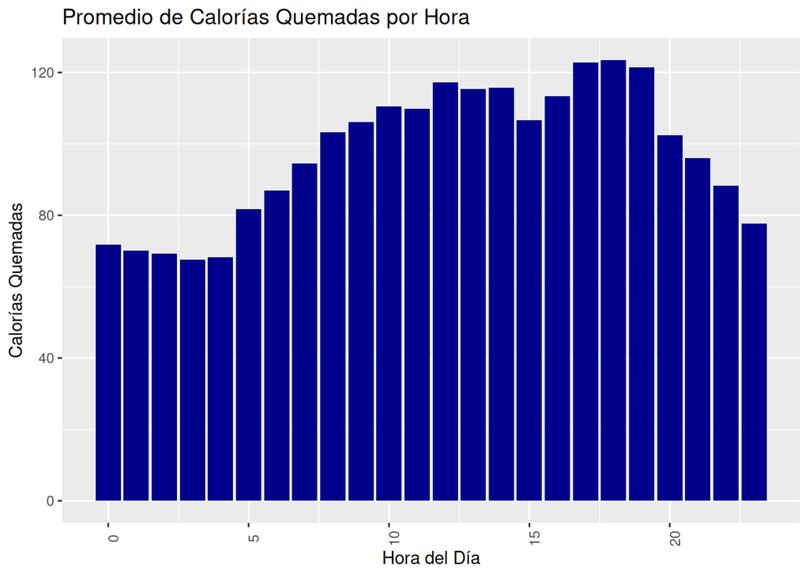

```r
sub_calorias_horas <- calorias %>%
  mutate(ActivityHour = mdy_hms(ActivityHour, tz = "UTC")) %>%
  mutate(hour = hour(ActivityHour))

resumen <- sub_calorias_horas %>%
  group_by(hour) %>%
  summarise(promedio_calorias = mean(Calories, na.rm = TRUE))
ggplot(data = resumen, aes(x = hour, y = promedio_calorias)) +
  geom_col(stat = "identity", fill = 'darkblue') +
  theme(axis.text.x = element_text(angle = 90)) +
  labs(title = "Promedio de Calorías Quemadas por Hora",
       x = "Hora del Día",
       y = "Calorías Quemadas")
```

- Al agrupar nuestro conjunto de datos en términos de las horas del día podemos observar que los **usuarios queman más calorías entre las 17:00 a 19:00**

```r
intensidad_horas <- intensidad_limp %>%
  mutate(hour = hour(activityhour))

resumen_int <- intensidad_horas %>%
  group_by(hour)
head(resumen_int,150)
```

| id | activityhour | totalintensity | averageintensity | hour |
| --- | --- | --- | --- | --- |
| 1503960366 | 2016-04-12 00:00:00 | 20 | 0.333333 | 0 |
| 1503960366 | 2016-04-12 01:00:00 | 8 | 0.133333 | 1 |
| 1503960366 | 2016-04-12 02:00:00 | 7 | 0.116667 | 2 |
| 1503960366 | 2016-04-12 03:00:00 | 0 | 0.000000 | 3 |
| 1503960366 | 2016-04-12 04:00:00 | 0 | 0.000000 | 4 |
| 1503960366 | 2016-04-12 05:00:00 | 0 | 0.000000 | 5 |
| 1503960366 | 2016-04-12 06:00:00 | 0 | 0.000000 | 6 |
| 1503960366 | 2016-04-12 07:00:00 | 0 | 0.000000 | 7 |
| 1503960366 | 2016-04-12 08:00:00 | 13 | 0.216667 | 8 |
| 1503960366 | 2016-04-12 09:00:00 | 30 | 0.500000 | 9 |

[output cut: 140 more lines]

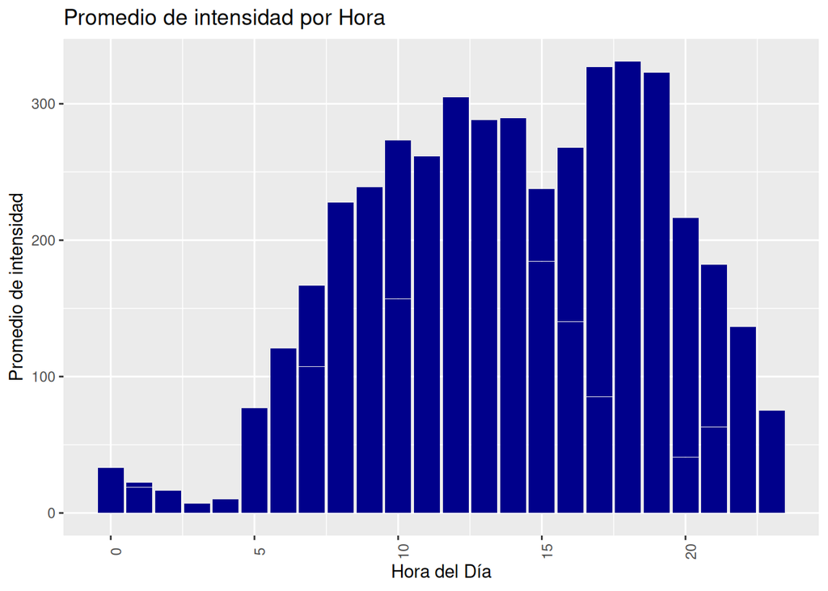

```r
ggplot(data = resumen_int, aes(x = hour, y = averageintensity)) +
  geom_col(stat = "identity", fill = 'darkblue') +
  theme(axis.text.x = element_text(angle = 90)) +
  labs(title = "Promedio de intensidad por Hora",
       x = "Hora del Día",
       y = "Promedio de intensidad")
```

```r
track_peso_limp %>%
  select(-id,-date,-ismanualreport ) %>%
  summary()
```

```
##     weightkg       weightpounds        bmi
##  Min.   : 52.60   Min.   :116.0   Min.   :21.45
##  1st Qu.: 61.40   1st Qu.:135.4   1st Qu.:23.96
##  Median : 62.50   Median :137.8   Median :24.39
##  Mean   : 72.04   Mean   :158.8   Mean   :25.19
##  3rd Qu.: 85.05   3rd Qu.:187.5   3rd Qu.:25.56
##  Max.   :133.50   Max.   :294.3   Max.   :47.54
```

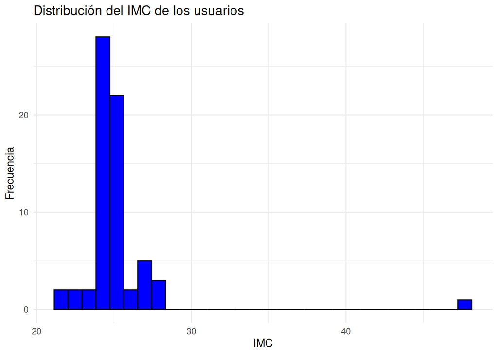

```r
graf <- track_peso_limp %>%
  select(-date,-ismanualreport) %>%
  group_by(bmi)

ggplot(graf, mapping = aes(x = bmi)) +
  geom_histogram( fill = "blue", color = "black") +
  labs(title = "Distribución del IMC de los usuarios",
       x = "IMC",
       y = "Frecuencia") +
  theme_minimal()
```

- Algunas conclusiones clave que podemos obtener de este marco de datos para entender mejor a nuestra población es que según la [Clasificación de índice de masa corporal ofrecida por el gobierno de México](https://www.gob.mx/issste/articulos/que-es-el-indice-de-masa-corporal) **el promedio del índice de masa corporal de nuestra población es de 25.19, lo cuál indica que existe un ligero sobre peso por parte de nuestra población**.
- Cabe resalta que como **IMC máximo tenemos datos de 47.54**, lo cuál se considera obesidad mórbida según la clasificación en la que nos estamos basando y como **IMC mínimo es de 21.45, lo cuál cae en la categría de IMC ideal**.

```r
tiempo_sueno_limp %>%
  select(-id,-sleepday)
```

| totalsleeprecords | totalminutesasleep | totaltimeinbed | day | difsueno_min | totalminutesasleephr | totaltimeinbedhr |
| --- | --- | --- | --- | --- | --- | --- |
| 1 | 327 | 346 | 2016-04-12 | 19 | 5.4500000 | 5.766667 |
| 2 | 384 | 407 | 2016-04-13 | 23 | 6.4000000 | 6.783333 |
| 1 | 412 | 442 | 2016-04-15 | 30 | 6.8666667 | 7.366667 |
| 2 | 340 | 367 | 2016-04-16 | 27 | 5.6666667 | 6.116667 |
| 1 | 700 | 712 | 2016-04-17 | 12 | 11.6666667 | 11.866667 |
| 1 | 304 | 320 | 2016-04-19 | 16 | 5.0666667 | 5.333333 |
| 1 | 360 | 377 | 2016-04-20 | 17 | 6.0000000 | 6.283333 |
| 1 | 325 | 364 | 2016-04-21 | 39 | 5.4166667 | 6.066667 |
| 1 | 361 | 384 | 2016-04-23 | 23 | 6.0166667 | 6.400000 |
| 1 | 430 | 449 | 2016-04-24 | 19 | 7.1666667 | 7.483333 |

[output cut: 403 more lines]

```r
summary(tiempo_sueno_limp)
```

```
##        id              sleepday         totalsleeprecords totalminutesasleep
##  Min.   :1.504e+09   Length:413         Min.   :1.000     Min.   : 58.0
##  1st Qu.:3.977e+09   Class :character   1st Qu.:1.000     1st Qu.:361.0
##  Median :4.703e+09   Mode  :character   Median :1.000     Median :433.0
##  Mean   :5.001e+09                      Mean   :1.119     Mean   :419.5
##  3rd Qu.:6.962e+09                      3rd Qu.:1.000     3rd Qu.:490.0
##  Max.   :8.792e+09                      Max.   :3.000     Max.   :796.0
##  totaltimeinbed       day                          difsueno_min
##  Min.   : 61.0   Min.   :2016-04-12 00:00:00.00   Min.   :  0.00
##  1st Qu.:403.0   1st Qu.:2016-04-19 00:00:00.00   1st Qu.: 17.00
##  Median :463.0   Median :2016-04-27 00:00:00.00   Median : 25.00
##  Mean   :458.6   Mean   :2016-04-26 12:40:05.80   Mean   : 39.17
##  3rd Qu.:526.0   3rd Qu.:2016-05-04 00:00:00.00   3rd Qu.: 40.00
##  Max.   :961.0   Max.   :2016-05-12 00:00:00.00   Max.   :371.00
##  totalminutesasleephr totaltimeinbedhr
##  Min.   : 0.9667      Min.   : 1.017
##  1st Qu.: 6.0167      1st Qu.: 6.717
##  Median : 7.2167      Median : 7.717
##  Mean   : 6.9911      Mean   : 7.644
##  3rd Qu.: 8.1667      3rd Qu.: 8.767
##  Max.   :13.2667      Max.   :16.017
```

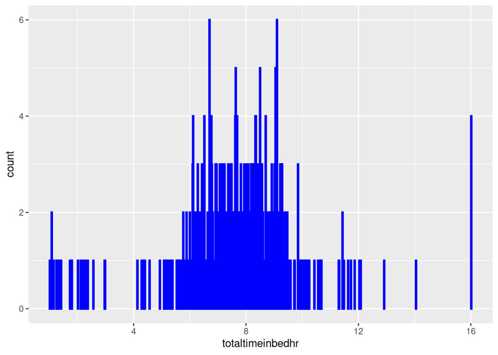

```r
ggplot(data = tiempo_sueno_limp, mapping = aes( x = totaltimeinbedhr)) + geom_bar(color = "blue" , size = 1)
```

## 4.1 Fusionando datos

Antes de comenzar con las visualizaciones finales de datos, necesito fusionar dos data sets, los cuales son act_limp y tiempo_sueno_limp por medio de los vectores id y fecha.

```r
merged_data <- merge(tiempo_sueno_limp, act_diaria_limp, by=c('id', 'day'))
head(merged_data)
```

|  | id | day | sleepday | totalsleeprecords | totalminutesasleep | totaltimeinbed | difsueno_min | totalminutesasleephr | totaltimeinbedhr | activitydate | totalsteps | totaldistance | trackerdistance | veryactivedistance | moderatelyactivedistance | lightactivedistance | sedentaryactivedistance | veryactiveminutes | fairlyactiveminutes | lightlyactiveminutes | sedentaryminutes | calories | distanciatotal | comparar | error_absoluto | minutosactivos |
| --- | --- | --- | --- | --- | --- | --- | --- | --- | --- | --- | --- | --- | --- | --- | --- | --- | --- | --- | --- | --- | --- | --- | --- | --- | --- | --- |
| 1 | 1503960366 | 2016-04-12 | 4/12/2016 12:00:00 AM | 1 | 327 | 346 | 19 | 5.450000 | 5.766667 | 4/12/2016 | 13162 | 8.50 | 8.50 | 1.88 | 0.55 | 6.06 | 0 | 25 | 13 | 328 | 728 | 1985 | 8.49 | FALSE | 1.000005e-02 | 1094 |
| 2 | 1503960366 | 2016-04-13 | 4/13/2016 12:00:00 AM | 2 | 384 | 407 | 23 | 6.400000 | 6.783333 | 4/13/2016 | 10735 | 6.97 | 6.97 | 1.57 | 0.69 | 4.71 | 0 | 21 | 19 | 217 | 776 | 1797 | 6.97 | FALSE | 2.980232e-07 | 1033 |
| 3 | 1503960366 | 2016-04-15 | 4/15/2016 12:00:00 AM | 1 | 412 | 442 | 30 | 6.866667 | 7.366667 | 4/15/2016 | 9762 | 6.28 | 6.28 | 2.14 | 1.26 | 2.83 | 0 | 29 | 34 | 209 | 726 | 1745 | 6.23 | FALSE | 5.000019e-02 | 998 |
| 4 | 1503960366 | 2016-04-16 | 4/16/2016 12:00:00 AM | 2 | 340 | 367 | 27 | 5.666667 | 6.116667 | 4/16/2016 | 12669 | 8.16 | 8.16 | 2.71 | 0.41 | 5.04 | 0 | 36 | 10 | 221 | 773 | 1863 | 8.16 | FALSE | 1.490116e-07 | 1040 |
| 5 | 1503960366 | 2016-04-17 | 4/17/2016 12:00:00 AM | 1 | 700 | 712 | 12 | 11.666667 | 11.866667 | 4/17/2016 | 9705 | 6.48 | 6.48 | 3.19 | 0.78 | 2.51 | 0 | 38 | 20 | 164 | 539 | 1728 | 6.48 | FALSE | 8.881784e-16 | 761 |
| 6 | 1503960366 | 2016-04-19 | 4/19/2016 12:00:00 AM | 1 | 304 | 320 | 16 | 5.066667 | 5.333333 | 4/19/2016 | 15506 | 9.88 | 9.88 | 3.53 | 1.32 | 5.03 | 0 | 50 | 31 | 264 | 775 | 2035 | 9.88 | FALSE | 1.192093e-07 | 1120 |

# 5. Visualizaciones

Una vez completado el análisis, crearemos algunas visualizaciones de datos. Las visualizaciones deben comunicar claramente las conclusiones y recomendaciones de alto nivel junto con los hallazgos clave.

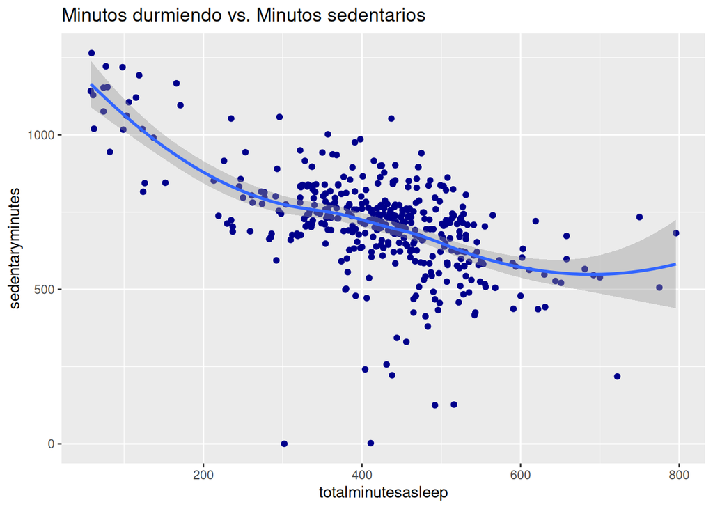

```r
ggplot(data=merged_data, aes(x=totalminutesasleep, y=sedentaryminutes)) +
geom_point(color='darkblue') + geom_smooth() +
  labs(title="Minutos durmiendo vs. Minutos sedentarios")
```

- Podemos observar una tendencia negativa del tiempo que las personas pasan durmiendo y el tiempo sedentario, lo que significa que el tiempo en estado sedentario las personas no lo pasan precisamente durmiendo.
- Una recomendación que puede dar Bellabeat para sus futuros usuarios es reducir estos tiempos de sedentarismo durante el día.

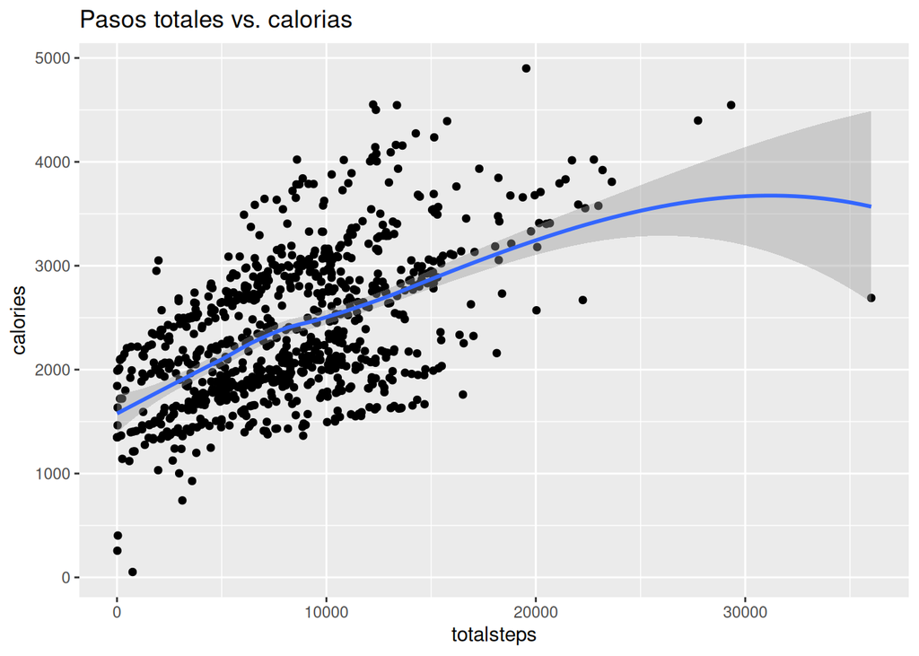

```r
ggplot(data= act_diaria_limp, aes(x=totalsteps, y=calories)) +
  geom_point() + geom_smooth() + labs(title="Pasos totales vs. calorias")
```

- Podemos observar una correlación positiva entre los pasos totales que damos y las calorías que quemamos.

# 6. Recomensaciones empresariales

## 7. Agradecimientos.

Agradezco el tiempo y la disposición de leer completo mi primer análisis de datos. Este es un caso práctico propuesto por la última fase del curso de [Análisis de datos de Google](https://www.coursera.org/programs/analisis-de-datos-google-2024-z0buk/professional-certificates/analisis-de-datos-de-google?collectionId=QYSbq) impartido por Coursera.